# Fortune 500 Analysis: What Makes a Company Successful?

By: Alan Cheng, Chris Desrochers, Sam LeDoux

### Background and Motivation

Fortune Magazine’s [Fortune 500 list](https://fortune.com/fortune500/) is a ranking of the 500 largest public and private United States corporations based on their total revenues per fiscal year. This list includes some of the most well known companies in the United States, such as Walmart, Microsoft, and FedEx. Additionally, the 2019 Fortune 500 companies represent about two-thirds of the entire United State’s Gross Domestic Product, adding up to a total revenue of $13.7 trillion, total profits of $1.1 trillion, and total market value of $22.5 trillion. These 500 companies alone also contribute to 17% of the gross world product and employ 28.7 million people across the world, 0.4% of the Earth’s total population.

With the Fortune 500 companies having such a significant impact on the national and global economies, we were interested in further analyzing these companies’ financial data and explore what factors made them so successful. Specifically, we wanted to identify trends among more successful companies and if a company’s revenue correlates with its number of employees, profits, assets, and/or market_value. Ultimately, our analysis would help us to better identify what other factors may affect or correlate with a company’s revenue, thereby impacting their ranking on the Fortune 500 list.

### Analysis Questions

To further analyze the Fortune 500 list, we attempted to answer the following question:

Is there a relationship between a companies ranking/revenue and their number of employees, profit, assets, and/or market value?

### Data Overview

We used a dataset of 2019 Fortune 500 company information retrieved from someka.net. This dataset includes the following information for each company:

- Rank
- Company Name
- Number of Employees
- Rank Change (compared to the previous fiscal year)
- Revenue
- Revenue Change (compared to the previous fiscal year)
- Profit
- Profit Change (compared to the previous fiscal year)
- Assets
- Market Value as of the end of the 2019 fiscal year (March 31, 2019)

You can read more about the dataset [here](https://www.someka.net/excel-template/fortune-500-excel-list/).

## Part 1: Data Collection

We first need to download the excel spreadsheet of our dataset from the someka.net website. Then, we have to import the spreadsheet into RStudio so we can perform analysis on the data.

Before we begin importing the excel data, we need to ensure that all of the required libraries are loaded.

```r
library(tidyverse)
library(readxl)
```

The [tidyverse](https://www.tidyverse.org/) library is a collection of R packages that are crucial for data science. This library includes [ggplot2](https://ggplot2.tidyverse.org/), [dplyr](https://dplyr.tidyverse.org/), [tidyr](https://tidyr.tidyverse.org/), [readr](https://readr.tidyverse.org/), [purrr](https://purrr.tidyverse.org/), [tibble](https://tibble.tidyverse.org/), [stringr](https://stringr.tidyverse.org/), and [forcats](https://forcats.tidyverse.org/) packages which are used to model, transform, and visualize data. The [readxl](https://readxl.tidyverse.org/) package allows us to read data from excel files.

The following code reads the data from the Microsoft excel file into a dataframe, a two-dimensional table. The excel file has some formatting and extraneous information in the first few rows, so we use the “skip = 6” option to skip over these irrelevant rows and start reading information from the seventh line where the actual data begins. The “New Names: …” problem just signifies that some columns did not have any headers or column names so it auto-filled header names for these columns.

```r
fortune_500_data <- read_excel("C:/Users/Alan Cheng/Desktop/Fortune 500 US List 2019_Someka V1.xlsx", skip = 6)
```

```
## * `` -> ...1
## * `` -> ...2
## * `` -> ...4
## * `` -> ...6
## * `` -> ...7
## * ... and 3 more problems
```

```r
fortune_500_data
```

```
## # A tibble: 501 x 10
##    ...1  ...2  `Company Info` ...4  `KEY FINANCIALS` ...6  ...7  ...8  ...9
##    <chr> <chr> <chr>          <chr> <chr>            <chr> <chr> <chr> <chr>
##  1 Rank  Comp~ Number of Emp~ "Cha~ "Revenues\r\n($~ "Rev~ "Pro~ "Pro~ "Ass~
##  2 1     Walm~ 2200000        "-"   "514405"         "2.7~ "667~ "-0.~ "219~
##  3 2     Exxo~ 71000          "-"   "290212"         "0.1~ "208~ "5.7~ "346~
##  4 3     Apple 132000         "1"   "265595"         "0.1~ "595~ "0.2~ "365~
##  5 4     Berk~ 389000         "-1"  "247837"         "2.4~ "402~ "-0.~ "707~
##  6 5     Amaz~ 647500         "3"   "232887"         "0.3~ "100~ "2.3~ "162~
##  7 6     Unit~ 300000         "-1"  "226247"         "0.1~ "119~ "0.1~ "152~
##  8 7     McKe~ 68000          "-1"  "208357"         "4.9~ "67"  "-0.~ "603~
##  9 8     CVS ~ 295000         "-1"  "194579"         "5.2~ "-59~ "-1.~ "196~
## 10 9     AT&T  268220         "-"   "170756"         "6.4~ "193~ "-0.~ "531~
## # ... with 491 more rows, and 1 more variable: ...10 <chr>
```

## Part 2: Data Processing

As we can see in the initial dataframe, the column header names are random and meaningless. Also, we can that the column headers from the excel table were read into the first row of the dataframe. To tidy the data and make the dataframe easier to understand, we first rename all of the columns header with proper descriptive names, and then remove the first row as it is supposed to be a header and is not actual data.

```r
# Renaming each column
colnames(fortune_500_data)[1] <- "rank"
colnames(fortune_500_data)[2] <- "company_name"
colnames(fortune_500_data)[3] <- "num_employees"
colnames(fortune_500_data)[4] <- "rank_change"
colnames(fortune_500_data)[5] <- "revenue"
colnames(fortune_500_data)[6] <- "revenue_change"
colnames(fortune_500_data)[7] <- "profit"
colnames(fortune_500_data)[8] <- "profit_change"
colnames(fortune_500_data)[9] <- "assets"
colnames(fortune_500_data)[10] <- "market_value"

# Remove the first row of the dataframe
fortune_500_data <- fortune_500_data[-1,]
fortune_500_data
```

```
## # A tibble: 500 x 10
##    rank  company_name num_employees rank_change revenue revenue_change profit
##    <chr> <chr>        <chr>         <chr>       <chr>   <chr>          <chr>
##  1 1     Walmart      2200000       -           514405  2.79999999999~ 6670
##  2 2     Exxon Mobil  71000         -           290212  0.188          20840
##  3 3     Apple        132000        1           265595  0.159          59531
##  4 4     Berkshire H~ 389000        -1          247837  2.4E-2         4021
##  5 5     Amazon.com   647500        3           232887  0.309          10073
##  6 6     UnitedHealt~ 300000        -1          226247  0.125          11986
##  7 7     McKesson     68000         -1          208357  4.90000000000~ 67
##  8 8     CVS Health   295000        -1          194579  5.29999999999~ -594
##  9 9     AT&T         268220        -           170756  6.40000000000~ 19370
## 10 10    Amerisource~ 20500         2           167939~ 9.69999999999~ 1658.4
## # ... with 490 more rows, and 3 more variables: profit_change <chr>,
## #   assets <chr>, market_value <chr>
```

Now that our data is organized, we can see that all the data is formatted as characters, but some columns only have numbers and should be formatted as numerical values. So, the data type for certain columns needs to be corrected in order for us to effectively analyze the data later on. As such, we need to convert all numerical data from characters into numerical values (i.e. integers and floats).

```r
# Convert the rank, num_employees, rank_change, revenue, revenue_change, profit, profit_change, assets, and market_value columns to numerical values.
fortune_500_data$rank <- as.numeric(fortune_500_data$rank)
fortune_500_data$num_employees <- as.numeric(fortune_500_data$num_employees)
fortune_500_data$rank_change <- suppressWarnings(as.numeric(fortune_500_data$rank_change))
fortune_500_data$revenue <- as.numeric(fortune_500_data$revenue)
fortune_500_data$revenue_change <- suppressWarnings(as.numeric(fortune_500_data$revenue_change))
fortune_500_data$profit <- as.numeric(fortune_500_data$profit)
fortune_500_data$profit_change <- suppressWarnings(as.numeric(fortune_500_data$profit_change))
fortune_500_data$assets <- as.numeric(fortune_500_data$assets)
fortune_500_data$market_value <- suppressWarnings(as.numeric(fortune_500_data$market_value))

fortune_500_data
```

```
## # A tibble: 500 x 10
##     rank company_name num_employees rank_change revenue revenue_change profit
##    <dbl> <chr>                <dbl>       <dbl>   <dbl>          <dbl>  <dbl>
##  1     1 Walmart            2200000          NA 514405          0.0280  6670
##  2     2 Exxon Mobil          71000          NA 290212          0.188  20840
##  3     3 Apple               132000           1 265595          0.159  59531
##  4     4 Berkshire H~        389000          -1 247837          0.024   4021
##  5     5 Amazon.com          647500           3 232887          0.309  10073
##  6     6 UnitedHealt~        300000          -1 226247          0.125  11986
##  7     7 McKesson             68000          -1 208357          0.049     67
##  8     8 CVS Health          295000          -1 194579          0.053   -594
##  9     9 AT&T                268220          NA 170756          0.064  19370
## 10    10 Amerisource~         20500           2 167940.         0.0970  1658.
## # ... with 490 more rows, and 3 more variables: profit_change <dbl>,
## #   assets <dbl>, market_value <dbl>
```

Looking at the dataframe, we can see there are rows with NA values for certain attributes. The NA values for rank_change signify no change in ranking from the previous year, so we can replace all of those NA values with 0. However, the other NA values, such as those in the profit_change and market_value columns, cannot be replaced with reasonable values. As such, we can remove rows with NA values for profit_change or market_value since they will not be useful for our analysis.

```r
# Replace NA values in rank_change column with 0
fortune_500_data$rank_change <- replace_na(fortune_500_data$rank_change, 0)

# Remove all rows with NA values
fortune_500_data <- na.omit(fortune_500_data)

fortune_500_data
```

```
## # A tibble: 421 x 10
##     rank company_name num_employees rank_change revenue revenue_change profit
##    <dbl> <chr>                <dbl>       <dbl>   <dbl>          <dbl>  <dbl>
##  1     1 Walmart            2200000           0 514405          0.0280  6670
##  2     2 Exxon Mobil          71000           0 290212          0.188  20840
##  3     3 Apple               132000           1 265595          0.159  59531
##  4     4 Berkshire H~        389000          -1 247837          0.024   4021
##  5     5 Amazon.com          647500           3 232887          0.309  10073
##  6     6 UnitedHealt~        300000          -1 226247          0.125  11986
##  7     7 McKesson             68000          -1 208357          0.049     67
##  8     8 CVS Health          295000          -1 194579          0.053   -594
##  9     9 AT&T                268220           0 170756          0.064  19370
## 10    10 Amerisource~         20500           2 167940.         0.0970  1658.
## # ... with 411 more rows, and 3 more variables: profit_change <dbl>,
## #   assets <dbl>, market_value <dbl>
```

Now, our data is ready for the next step of the data science pipeline: Exploratory Analysis and Data Visualization.

## Part 3: Exploratory Analysis and Data Visualization

Now that we’ve seen the data organized into tables, we’re going to want to get a better understanding of what the data all really means, and what relationships we can find in it. First, we’ll take a look at the really basic aspects of our dataset - things like measures of central tendency, trends, distributions, etc. In particular, since we’re going to be focusing so much on revenue, let’s explore and analyze the revenue of the Fortune 500 companies first.

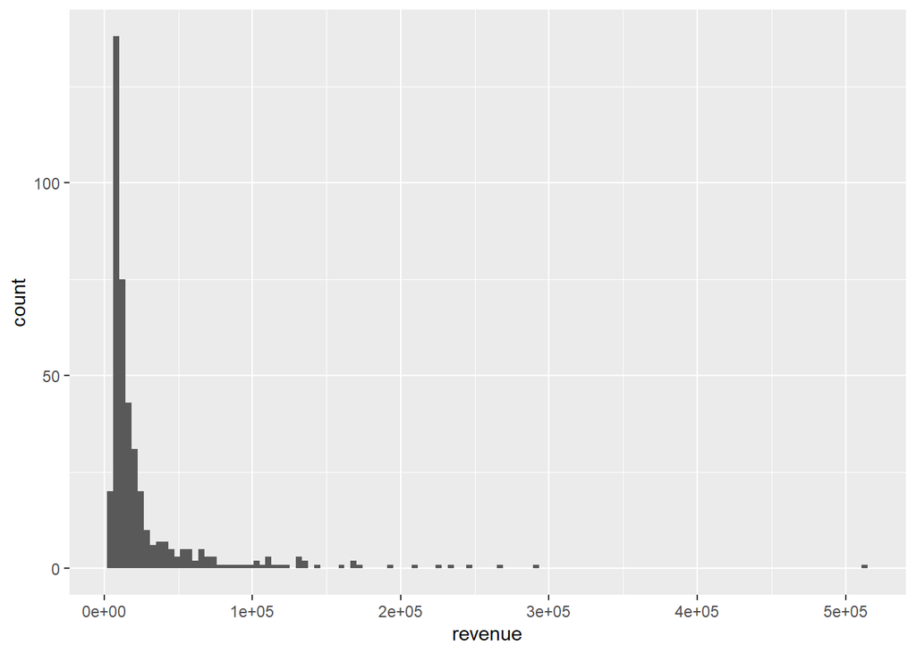

```r
# Look at the distribution of the Revenue
fortune_500_data%>%ggplot(aes(x = revenue)) + geom_histogram(bins = 125)
```

```r
# Basic data about Revenue - mean, median, etc
summary(fortune_500_data$revenue)
```

```
##    Min. 1st Qu.  Median    Mean 3rd Qu.    Max.
##    5575    8080   13033   28419   23747  514405
```

```r
# We can see the skew by comparing the differences in quartiles
fortune_500_data %>%
  summarize(med_rev = median(revenue), q1_rev = quantile(revenue, 1/4),
            q3_rev = quantile(revenue, 3/4)) %>%
  mutate(q1_diff = med_rev - q1_rev, q3_diff = q3_rev - med_rev) %>%
  select(q1_diff, q3_diff)
```

```
## # A tibble: 1 x 2
##   q1_diff q3_diff
##     <dbl>   <dbl>
## 1    4953  10714.
```

Now that we’ve looked at the distribution of the revenue data and looked its summary statistics, we can start to notice something. Since the distribution chart peeks so far to the left, and trails off to the right, we would suspect that the data has a rightward skew. The summary table backs this up - the mean (the average of the revenue variable) is over two times larger than the median; this is a trait associated with skewed data. What this suggests is that the revenue data is primarily distributed at the lower values, and outliers lying to the right will greatly affect any analysis we attempt to make, skewing our data and making our results innacurate. Our second table confirms this skew, as the quartile difference is massive - a 2:1 ration between the sizes of quartile 3 and quartile 1. Next, we will perform measures to confirm that these are in fact outliers, and if so, do something about them.

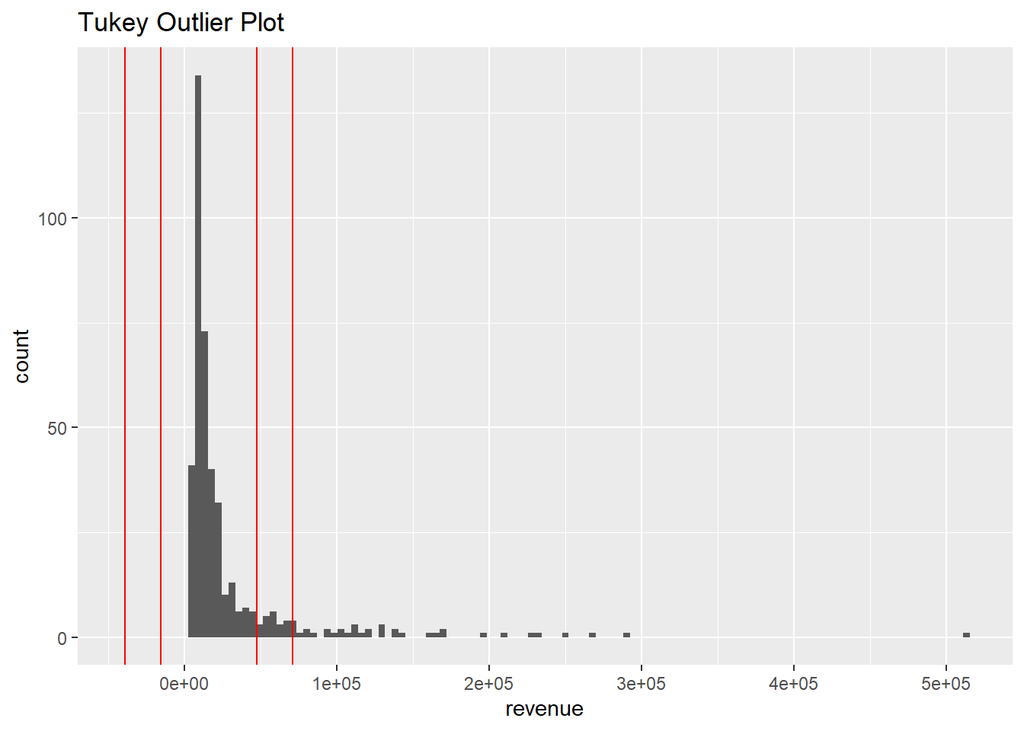

```r
# Tukey Outlier Code
outlier_df <- fortune_500_data %>%
  summarize(q1=quantile(revenue, 1/4), q3=quantile(revenue, 3/4), iqr=IQR(revenue)) %>%
  slice(rep(1, 2)) %>%
  mutate(multiplier = c(1.5, 3)) %>%
  mutate(lower_outlier_limit = q1 - multiplier * iqr) %>%
  mutate(upper_outlier_limit = q3 + multiplier * iqr)

#Plotting the Tukey Outlier Data
fortune_500_data %>%
  ggplot(aes(x=revenue)) +
    geom_histogram(bins=125) +
    geom_vline(aes(xintercept=lower_outlier_limit), data=outlier_df, color="red") +
    geom_vline(aes(xintercept=upper_outlier_limit), data=outlier_df, color="red") + labs(title  = "Tukey Outlier Plot")
```

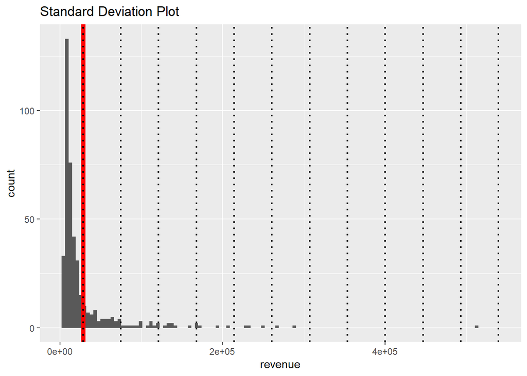

```r
# Calculating and plotting Standard deviations
sds_plot <- seq(0,11)
sd_df <- fortune_500_data %>%
  summarize(mean_rev = mean(revenue), sd_rev = sd(revenue)) %>%
  slice(rep_along(sds_plot, 1)) %>%
  mutate(sd_to_plot=sds_plot) %>%
  mutate(sd_val = mean_rev + sd_to_plot * sd_rev)

fortune_500_data %>%
ggplot(aes(x=revenue)) +
    geom_histogram(bins=125) +
    geom_vline(aes(xintercept=mean(revenue)), col="red", size=2) +
    geom_vline(aes(xintercept = sd_val), data=sd_df,
               linetype=3, size=.8) + labs(title = "Standard Deviation Plot")
```

These plots show how skewed the dataset is - the red lines in the Tukey plot show that a large portion of data representing higher revenues is well beyond these lines and thus would be considered outliers. Companies such as Walmart made so much in revenue that trying to analyze any trends with them in the dataset will likely make our analyses wildly innacurate. The Standard Deviation Plot shows that many of the Fortune 500 companies are several standard deviations away from the mean, Walmart lying over TEN standard deviations away. Thus, we can also conclude how the more properous companies have much significantly higher revenues than most other companies. For our basic analysis in this section, we have decided to disregard data outside of 3 standard deviations as over 99% of data would be normally expected to fall within those bounds. In this case, companies with a value over 167653.8 for their revenue will not be included in the charts below.

```r
rev_cutoff = mean(fortune_500_data$revenue) + 3 * sd(fortune_500_data$revenue)
fort_no_ol <- fortune_500_data
fort_no_ol$fixed_rev <-
  ifelse(fortune_500_data$revenue>rev_cutoff, NA, fortune_500_data$revenue)
fort_no_ol <- na.omit(fort_no_ol)
fort_no_ol
```

```
## # A tibble: 411 x 11
##     rank company_name num_employees rank_change revenue revenue_change profit
##    <dbl> <chr>                <dbl>       <dbl>   <dbl>          <dbl>  <dbl>
##  1    11 Chevron              48600           2  166339         0.236   14824
##  2    12 Ford Motor          199000          -1  160338         0.023    3677
##  3    14 Costco Whol~        194000           1  141576         0.0970   3134
##  4    15 Alphabet             98771           7  136819         0.234   30736
##  5    16 Cardinal He~         50200          -2  136809         0.053     256
##  6    17 Walgreens B~        299000           2  131537         0.113    5024
##  7    18 JPMorgan Ch~        256105           2  131412         0.154   32474
##  8    19 Verizon Com~        144500          -3  130863         0.038   15528
##  9    20 Kroger              453000          -3  121162        -0.012    3110
## 10    22 Fannie Mae            7400          -1  120101         0.069   15959
## # ... with 401 more rows, and 4 more variables: profit_change <dbl>,
## #   assets <dbl>, market_value <dbl>, fixed_rev <dbl>
```

To get a basic understanding of the trends in our data, we’ll first just look at some scatterplots of the basic information. We wanted to see how the number of employees, profit, assets, and market value relate to the revenue of the businesses in the Fortune 500. Since the revenue is the value we want to see change, that will be the y value for each chart, and each independent variable given will be the x value in its own respective chart. We will also generate a line of best fit for each graph to get a general idea of how each variable relates to the revenue data. This will offer us additional understanding of these factors correlate with the revenue data.

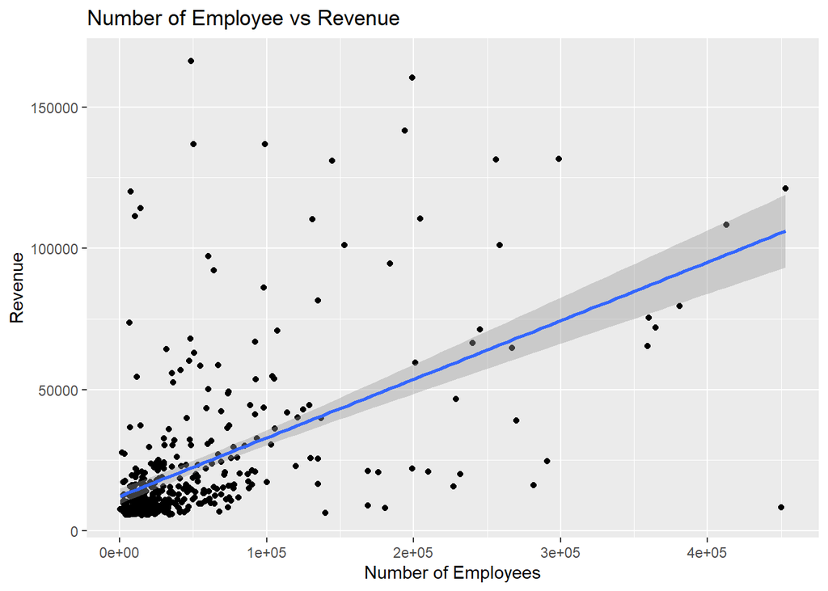

```r
#Create employee plot
fort_no_ol%>%arrange(revenue)%>%
  ggplot(aes(x = num_employees, y = fixed_rev)) + geom_point()+ geom_smooth(method = lm) + labs(title = "Number of Employee vs Revenue", x = "Number of Employees", y = "Revenue")
```

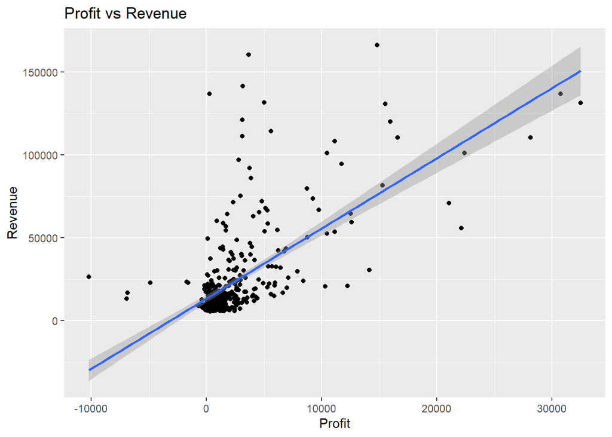

```r
#Create profit plot
fort_no_ol%>%
  ggplot(aes(x = profit, y = fixed_rev)) + geom_point()+ geom_smooth(method = lm) + labs(title = "Profit vs Revenue", x = "Profit", y = "Revenue")
```

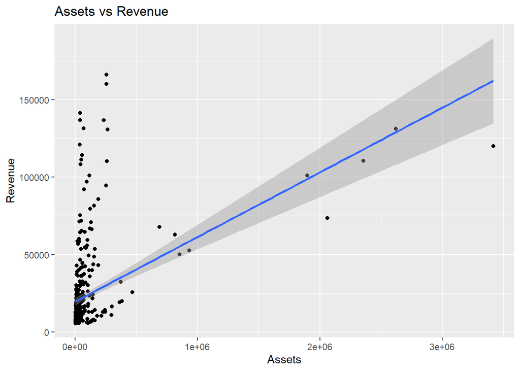

```r
#Create asset plot
fort_no_ol%>%
  ggplot(aes(x = assets, y = fixed_rev)) + geom_point()+ geom_smooth(method = lm)+ labs(title = "Assets vs Revenue", x = "Assets", y = "Revenue")
```

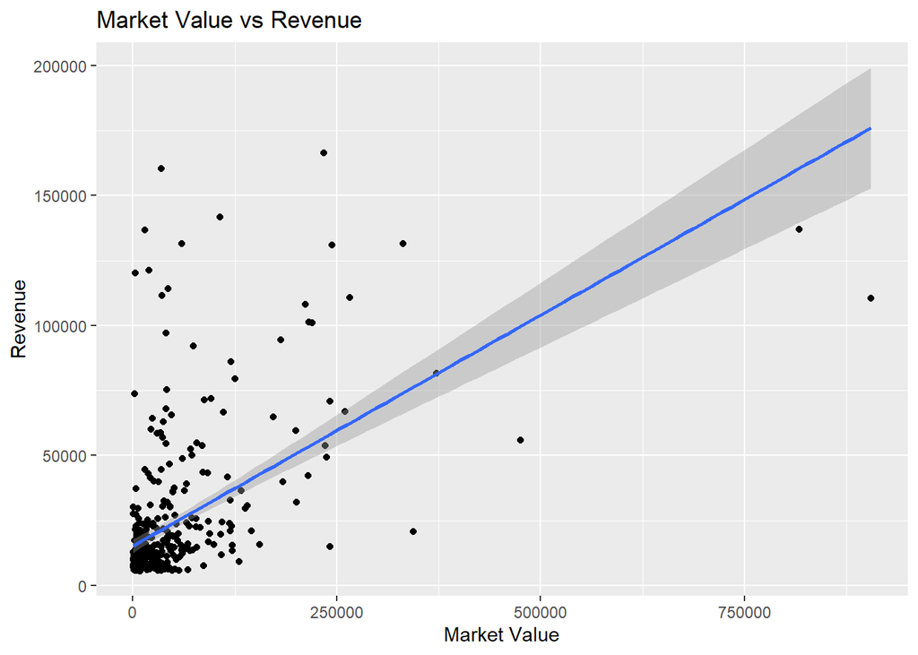

```r
#Create market plot
fort_no_ol%>%
  ggplot(aes(x = market_value, y = fixed_rev)) + geom_point()+ geom_smooth(method = lm)+ labs(title = "Market Value vs Revenue", x = "Market Value", y = "Revenue")
```

Looking at the graphs and their lines of best fit, the profit and number of employees seem to be the variables most correlated with revenue, but we’ll explore that beyond eye-balling in the following sections.

## Part 4: Machine Learning and Hypothesis Testing

We will now use a random forest to attempt to find a regression that describes company revenue based upon the number of employees, profit, assets, and the market value. Our goal will be to train a model, analyze each individual variable’s importance to the final model, and finally evaluate the model both visually and quantitatively.

In this first section, we will create two sets of data from our main fortune 500 dataframe, one of which will be used to train the model and one of which will be used to evaluate it. We do this by sampling half of the data, and putting it into train_set, and then storing the fortune 500 dataframe without those sampled entities into test_set.

Using the training set, we train the random forest on a linear regression model using the following base equation: revenue = num_employees + profit + assets + market_value

Of course there are constants that will be learned in front of each of the independent variables, but we did not show them in the above formula.

```r
set.seed(1234)
train_indices <- sample(nrow(fortune_500_data), nrow(fortune_500_data)/2)
train_set <- fortune_500_data[train_indices,]
test_set <- fortune_500_data[-train_indices,]
fortune_500_rf <- randomForest(revenue~num_employees+profit+assets+market_value, importance=TRUE, mtry=3, data=train_set)
```

Once the model has been created and trained, we look at the importance of each independent variable on the final graph. %IncMSE is a measure of how much the mean squared error increased when that specific variable was assigned randomized values. A higher %IncMSE thus means a variable is more important, because replacing it with random values resulted in a higher decrease in the performance of our model.

```r
round(importance(fortune_500_rf), 2)
```

```
##               %IncMSE IncNodePurity
## num_employees   22.44   71956739688
## profit          16.40   50378899113
## assets          17.02   52613753518
## market_value     9.89   49670533181
```

We will now look at the predictions our model makes on the testing set, by asking the model to predict the revenue of the entities in test_set, forming it as a dataframe, and then cleaning up the attribute name before adding it to the test_set dataframe.

```r
test_predict <- as.data.frame(predict(fortune_500_rf, test_set)) %>% rename(predicted_revenue = "predict(fortune_500_rf, test_set)")
test_set$predicted_revenue = test_predict$predicted_revenue
```

We now graph the revenue of each entity in the test_set in red, along with the predicted revenue for each entity in blue.

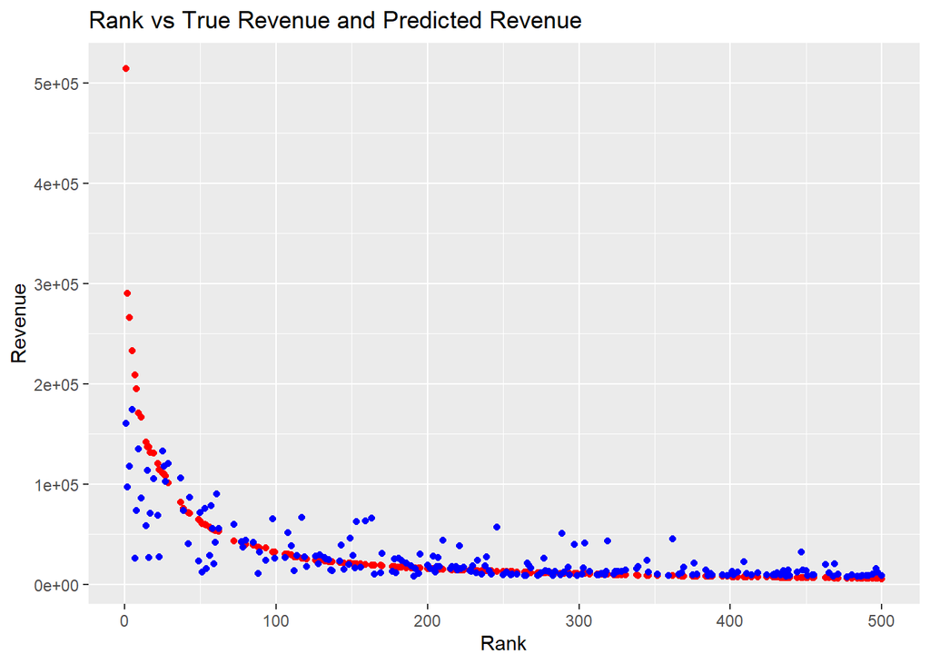

```r
ggplot(test_set, mapping = aes(x=rank)) + geom_point(aes(y=revenue), color="red") + geom_point(aes(y=predicted_revenue), color="blue") + labs(title = "Rank vs True Revenue and Predicted Revenue", x = "Rank", y = "Revenue")
```

Looking at the graph, it seems like the model is doing a mediocre job of fitting the data. It does not seem very tight to the true distribution, but it does somewhat follow the exponential decay-like form of the true data.

To quantitatively evaluate our model, we could look at mean squared error, but to make this value easier to interpret, we will look at the mean percent error. This will measure the average difference between the true value and our prediction divided by the true value. In other words, we are comparing the error of our model to the true value to get a better idea of how far off it is, because since our revenue values are somewhat high in order of magnitude, we could have a decently high mean square error that still indicates a solid regression.

```r
average_error_percent <- mean(abs(test_set$revenue - test_set$predicted_revenue)/test_set$revenue)
average_error_percent
```

```
## [1] 0.5583335
```

This value seems to confirm that our regression is not doing a phenomenal job of fitting the data. On average, our predictions were about 55% off from the true values, which is not a high accuracy at all.

Though this model was not successful, we will use a simple linear regression to further test our hypothesis that there is a relationship between revenue and these other attributes.

We now conduct a linear regression and look at the estimates for the correlations between each attribute and revenue, and their respective p-values.

```r
linreg <- lm(revenue~num_employees+profit+assets+market_value, data=fortune_500_data)
tidy(linreg)
```

```
## # A tibble: 5 x 5
##   term           estimate  std.error statistic  p.value
##   <chr>             <dbl>      <dbl>     <dbl>    <dbl>
## 1 (Intercept)   5097.     1515.           3.36 8.38e- 4
## 2 num_employees    0.200     0.0105      19.1  6.92e-59
## 3 profit           1.73      0.463        3.74 2.10e- 4
## 4 assets           0.0177    0.00544      3.24 1.28e- 3
## 5 market_value     0.101     0.0208       4.87 1.61e- 6
```

All of the regressions resulted in p-values below the alpha threshold of 0.05. Thus, there is a statistically significant relationship between each of the variables and revenue. On average, a company’s revenue will increase by about $200,000 per employee, $1.7 million per $1 million increase in profits, $17,600 per $1 million of assets, and about $100,000 per $1 million of market value.

It may seem contradictory that the mean percent error was so high, yet the linear regression was able to reject the null hypothesis. However, this makes sense because we saw that the dataset was largely jittery and varied, which would contribute to high error, despite a model being able to relatively well predict revenue, considering the variance in the orginial dataset.

## Part 5: Conclusion

Ultimately, we performed a variety of visualization and analysis on the 2019 Fortune 500 data to identify relationships between the various attributes given in the table. Despite the lack of success in predicting revenue using our model using the random forest, we were still able to learn about the distrobution of companies using this dataset; we saw that the data was largely positively skewed, which likely contributed to the difficulty we experienced in regressing the data. However, using a linear regression model was more successful in identifying relationships between variables as we identified statistically significant relationships between a company’s revenue and the number of employees, profit, assets, and market value. Thus, we can conclude that there does exist a relationship between a company’s revenue and other company data, but using these factors as predictors proves to be unreliable due to the significant outliers and variance in the dataset.